# Project2_Mai_Todd_Carlos

[figure not shown]

[figure not shown]

[figure not shown]

[figure not shown]

[figure not shown]

[figure not shown]

[figure not shown]

[figure not shown]

[figure not shown]

[figure not shown]

```r
# Load necessary library
library(ggplot2)

# List of categorical variables
numerical_vars <- c("age", "weight", "bmi", "height", "fracscore") # Update with your actual categorical variables

glow_bonemed_new <- glow_bonemed[,-c(1, 2, 3)]

# Loop to create jitter plots
for (i in 1:(length(numerical_vars)-1)) {
  for (j in (i+1):length(numerical_vars)) {
    p <- ggplot(glow_bonemed_new, aes(x = numerical_vars[i], y = numerical_vars[j])) +
         geom_jitter(width = 0.2, height = 0.2) +
         labs(title = paste("Jitter Plot of", numerical_vars[i], "vs", numerical_vars[j]))
    print(p)
  }
}
```

# There doesn’t appear to be much to glean from these scatter plots. They are all virtually identical. A square in the center of the plot with scattered points. No hint at any pattern. Not shown, I did the same for the categorical variables and got the same result. I’m not satisfied with this EDA so I’m going to take a different approach.

# Evaluating the Need for Transformation

# First, assess whether variables like BMI and age require transformation. This is typically done by examining their distribution and relationship with the response variable.

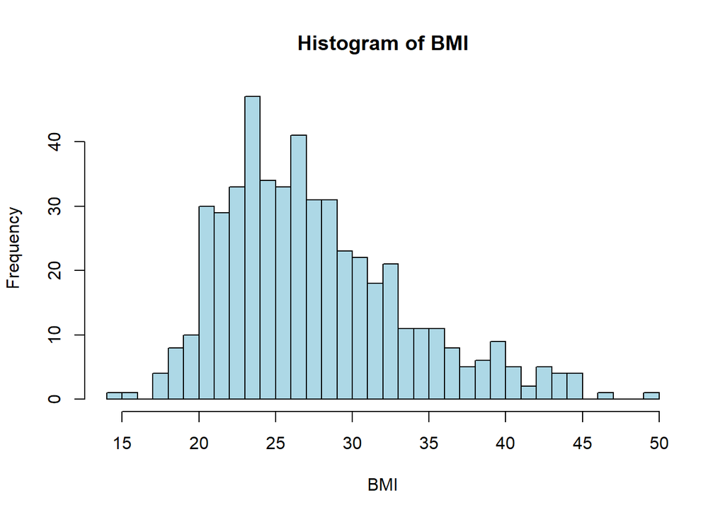

```r
data <- glow_bonemed
# Histogram for BMI
hist(data$bmi, main = "Histogram of BMI", xlab = "BMI", breaks = 30, col = "lightblue")
```

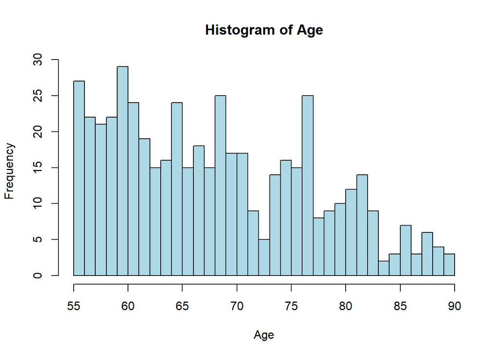

```r
# Histogram for Age
hist(data$age, main = "Histogram of Age", xlab = "Age", breaks = 30, col = "lightblue")
```

# The Histogram of Age shows a multi-model data set that is right skewed.  
# The Histogram of BMI shows a mostly normally distributed data set but right skewed.